# Regressão Logística Bayesiana aplicado em dados de Câncer de Mama

**Diego de Almeida Miranda - 133603**

## Bibliotecas utilizadas

Neste trabalho foram utilizadas as bibliotecas R2OpenBUGS e CODA. A biblioteca R2OpenBUGS é utilizada para treinar as Cadeias de Markov utilizadas no ajuste dos modelos, enquanto a biblioteca CODA é utilizada para gerar gráficos e imagens que nos ajude a interpretar a qualidade do ajuste desses modelos.

```r
base::require("R2OpenBUGS")
base::require("coda")
base::require("readr")
base::require("lattice")
```

## Os dados

Os atributos presentes neste conjunto de dados descrevem imagens digitalizadas pelo método NFA, do inglês fine needle aspiration, que consiste em penetrar uma fina agulha num tecido de aparência anormal, como um tumor, assim como uma biópsia. É comum a realização ultrassonografia durante uma sessão de NFA, pois isso ajuda a localizar a área de interesse, e é a partir da ultrassonografia que as imagens são geradas.

Este conjunto de dados está disponível para consulta desde 1995 e pode ser acessado em https://archive.ics.uci.edu/ml/ com o título *Breast Cancer Wisconsin (Diagnostic) Data Set*.

```r
df <- utils::read.csv("./data.csv")
utils::head(df, 10)
```

A data.frame: 10 × 33

|  | id <int> | diagnosis <chr> | radius_mean <dbl> | texture_mean <dbl> | perimeter_mean <dbl> | area_mean <dbl> | smoothness_mean <dbl> | compactness_mean <dbl> | concavity_mean <dbl> | concave.points_mean <dbl> | ⋯ | texture_worst <dbl> | perimeter_worst <dbl> | area_worst <dbl> | smoothness_worst <dbl> | compactness_worst <dbl> | concavity_worst <dbl> | concave.points_worst <dbl> | symmetry_worst <dbl> | fractal_dimension_worst <dbl> | X <lgl> |
| --- | --- | --- | --- | --- | --- | --- | --- | --- | --- | --- | --- | --- | --- | --- | --- | --- | --- | --- | --- | --- | --- |
| 1 | 842302 | M | 17.99 | 10.38 | 122.80 | 1001.0 | 0.11840 | 0.27760 | 0.30010 | 0.14710 | ⋯ | 17.33 | 184.60 | 2019.0 | 0.1622 | 0.6656 | 0.7119 | 0.2654 | 0.4601 | 0.11890 | NA |
| 2 | 842517 | M | 20.57 | 17.77 | 132.90 | 1326.0 | 0.08474 | 0.07864 | 0.08690 | 0.07017 | ⋯ | 23.41 | 158.80 | 1956.0 | 0.1238 | 0.1866 | 0.2416 | 0.1860 | 0.2750 | 0.08902 | NA |
| 3 | 84300903 | M | 19.69 | 21.25 | 130.00 | 1203.0 | 0.10960 | 0.15990 | 0.19740 | 0.12790 | ⋯ | 25.53 | 152.50 | 1709.0 | 0.1444 | 0.4245 | 0.4504 | 0.2430 | 0.3613 | 0.08758 | NA |
| 4 | 84348301 | M | 11.42 | 20.38 | 77.58 | 386.1 | 0.14250 | 0.28390 | 0.24140 | 0.10520 | ⋯ | 26.50 | 98.87 | 567.7 | 0.2098 | 0.8663 | 0.6869 | 0.2575 | 0.6638 | 0.17300 | NA |
| 5 | 84358402 | M | 20.29 | 14.34 | 135.10 | 1297.0 | 0.10030 | 0.13280 | 0.19800 | 0.10430 | ⋯ | 16.67 | 152.20 | 1575.0 | 0.1374 | 0.2050 | 0.4000 | 0.1625 | 0.2364 | 0.07678 | NA |
| 6 | 843786 | M | 12.45 | 15.70 | 82.57 | 477.1 | 0.12780 | 0.17000 | 0.15780 | 0.08089 | ⋯ | 23.75 | 103.40 | 741.6 | 0.1791 | 0.5249 | 0.5355 | 0.1741 | 0.3985 | 0.12440 | NA |
| 7 | 844359 | M | 18.25 | 19.98 | 119.60 | 1040.0 | 0.09463 | 0.10900 | 0.11270 | 0.07400 | ⋯ | 27.66 | 153.20 | 1606.0 | 0.1442 | 0.2576 | 0.3784 | 0.1932 | 0.3063 | 0.08368 | NA |
| 8 | 84458202 | M | 13.71 | 20.83 | 90.20 | 577.9 | 0.11890 | 0.16450 | 0.09366 | 0.05985 | ⋯ | 28.14 | 110.60 | 897.0 | 0.1654 | 0.3682 | 0.2678 | 0.1556 | 0.3196 | 0.11510 | NA |
| 9 | 844981 | M | 13.00 | 21.82 | 87.50 | 519.8 | 0.12730 | 0.19320 | 0.18590 | 0.09353 | ⋯ | 30.73 | 106.20 | 739.3 | 0.1703 | 0.5401 | 0.5390 | 0.2060 | 0.4378 | 0.10720 | NA |
| 10 | 84501001 | M | 12.46 | 24.04 | 83.97 | 475.9 | 0.11860 | 0.23960 | 0.22730 | 0.08543 | ⋯ | 40.68 | 97.65 | 711.4 | 0.1853 | 1.0580 | 1.1050 | 0.2210 | 0.4366 | 0.20750 | NA |

Aqui possuímos um total de 569 amostras, em linhas, e 33 atributos. Desses atributos, utilizaremos apenas 31, sendo *diagnosis* a variável resposta e o restante sendo variáveis descritivas. Abaixo temos uma descrição melhor sobre os principais atributos.

```
0. diagnosis: Diagnóstico do tumor, onde M é maligno e B é benigno;
1. radious: média das distâncias do centro aos pontos do perímetro;
2. texture: desvio padrão dos valores da escala de cinza;
3. perimeter: perímetro da região observada;
4. area: tamanho da área obserada;
5. smothness: variação local em comprimentos de raio;
6. compactness: (perimeter^2 / area) - 1;
7. concavity: severidade das porções côncavas do contorno;
8. concave points: número de pontos côncavos no contorno;
9. symmetry: simetria da região analisada;
10. fractal dimension: dimensão fractal da imagem.
```

Nota-se que, para cada um desses atributos, encontramos sua média, devio padrão e - o que é chamado de - pior caso. Conceitualmente, sabemos que a correlação entre a média de um atributo e o desvio padrão do mesmo será muito forte. Portanto, serão utilizados apenas o valor de desvio padrão obtido desses atributos, pois estes apresentaram melhor capacidade descritiva quando comparados com a média.

Podemos, então, remover as colunas que não serão utilizadas.

```r
# removendo colunas que são NA
df <- df[,colSums(is.na(df))<nrow(df)]
#
# removendo a variável ID
df <- df[-c(1)]
```

Conferindo a existência de dados NA:

```r
print(base::which(base::is.na(df)))
```

```
integer(0)
```

Transformando em valor numérico a variável *diagnosis*, onde "M" == 0 e "B" == 1.

```r
for(i in 1:nrow(df)){
    if(df[i,1] == 'M'){
        df[i,1] <- 0
    }
    else{
        df[i,1] <- 1
    }
}
```

Ajustando os dados para serem executados no R2OpenBUGS. Para isso, transformaremos cada atributo do nosso conjunto de dados em um vetor individual.

```r
#definindo as colunas como variáveis pra conseguir rodar no R2OpenBUGS
radius<-df$radius_se
texture<-df$texture_se
perimeter<-df$perimeter_se
area<-df$area_se
smoothness<-df$smoothness_se
compactness<-df$compactness_se
concavity<-df$concavity_se
concave_points<-df$concave.points_se
symmetry<-df$symmetry_se
fractal_dimension<-df$fractal_dimension_se

# construindo y
y = df$diagnosis
```

## Construção do primeiro modelo

```r
# N é numero de amostras
N <- 200
```

```r
# data são os nomes das variáveis que possui os dados a serem analisados
data<-list('y', 'N','area', 'texture', 'perimeter', 'radius', 'smoothness','compactness', 'concavity', 'concave_points', 'symmetry', 'fractal_dimension')

# os parametros a serem definidos
params<-c("beta0", "beta1", "beta2", "beta3", "beta4", "beta5", "beta6", "beta7", "beta8", "beta9", "beta10")

model <- function(){
    for(i in 1:N){
        y[i] ~ dbern(p[i])
        logit(p[i]) <- beta0 + beta1*area[i] + beta2*texture[i] + beta3*perimeter[i] + beta4*radius[i] + beta5*smoothness[i] + beta6*compactness[i] + beta7*concavity[i] + beta8*concave_points[i] + beta9*symmetry[i] + beta10*fractal_dimension[i]
    }
    beta0 ~ dnorm(0, .01)
    beta1 ~ dnorm(0, .01)
    beta2 ~ dnorm(0, .01)
    beta3 ~ dnorm(0, .01)
    beta4 ~ dnorm(0, .01)
    beta5 ~ dnorm(0, .01)
    beta6 ~ dnorm(0, .01)
    beta7 ~ dnorm(0, .01)
    beta8 ~ dnorm(0, .01)
    beta9 ~ dnorm(0, .01)
    beta10 ~ dnorm(0, .01)
}

# definindo valor inicial dos parâmetros
inits<-function(){list( beta0 = 0, beta1=0, beta2=0, beta3=0, beta4=0, beta5=0, beta6=0, beta7=0, beta8=0, beta9=0, beta10=0)}

#criando um arquivo com o modelo pra conseguir usa-lo na biblioteca
model.file <- file.path("/home/ddeam/Documentos/Bayesian", "model1.txt")
write.model(model, model.file)
```

```r
out1<-R2OpenBUGS::bugs(data, inits, params, model.file, n.chains = 1, n.iter=10000, n.burnin = 3000, n.thin = 1 , codaPkg = TRUE, DIC = TRUE)

line.coda1 <- R2OpenBUGS::read.bugs(out1)
```

```
Abstracting beta0 ... 7000 valid values
Abstracting beta1 ... 7000 valid values
Abstracting beta10 ... 7000 valid values
Abstracting beta2 ... 7000 valid values
Abstracting beta3 ... 7000 valid values
Abstracting beta4 ... 7000 valid values
Abstracting beta5 ... 7000 valid values
Abstracting beta6 ... 7000 valid values
Abstracting beta7 ... 7000 valid values
Abstracting beta8 ... 7000 valid values
Abstracting beta9 ... 7000 valid values
Abstracting deviance ... 7000 valid values
```

Antes de analisarmos as estatísticas da distribuição posteriori, devemos avaliar a convergência das cadeis.Neste caso, temos uma única cadeia e seu comportamento pode er observado na figura abaixo.

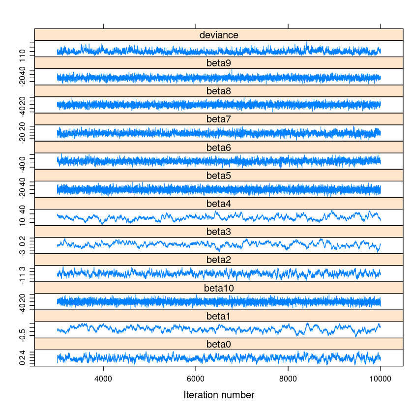

```r
lattice::xyplot(line.coda1)
```

Sabemos que o cenário ideal é que a cadeia varie de maneira estável em determinado intervalo, apresentando aparente uniformidade, como o *beta5* apresenta. Entretanto, os parâmetros de beta 1, 2, 3 e 4 não se mostram uniformes e a correção pode ser feita aumentando o valor definido em *thin* para 3.

```r
# mudança para thin de valor 3
out1<-R2OpenBUGS::bugs(data, inits, params, model.file, n.chains = 1, n.iter=10000, n.burnin = 3000, n.thin = 3 , codaPkg = TRUE, DIC = TRUE)

line.coda1 <- R2OpenBUGS::read.bugs(out1)
```

```
Abstracting beta0 ... 7000 valid values
Abstracting beta1 ... 7000 valid values
Abstracting beta10 ... 7000 valid values
Abstracting beta2 ... 7000 valid values
Abstracting beta3 ... 7000 valid values
Abstracting beta4 ... 7000 valid values
Abstracting beta5 ... 7000 valid values
Abstracting beta6 ... 7000 valid values
Abstracting beta7 ... 7000 valid values
Abstracting beta8 ... 7000 valid values
Abstracting beta9 ... 7000 valid values
Abstracting deviance ... 7000 valid values
```

Agora, vejamos novamente o comportamento da cadeia:

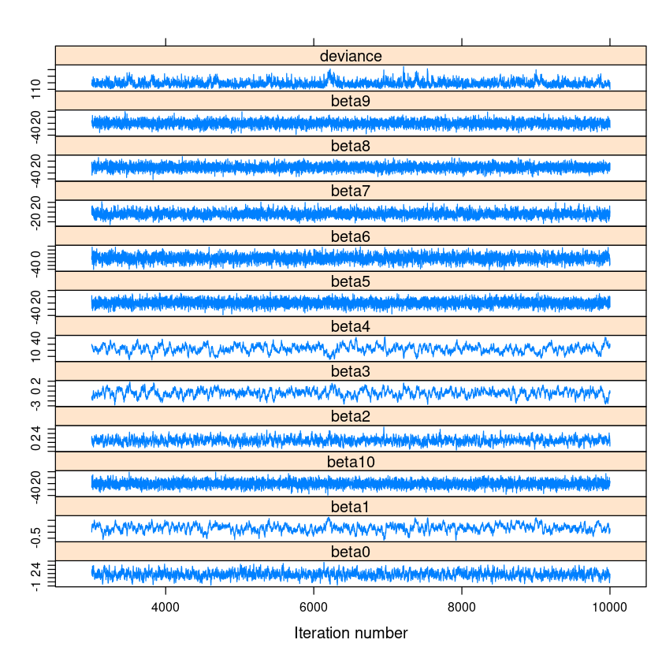

```r
lattice::xyplot(line.coda1)
```

O *beta2* e *beta0* obtiveram um ganho de estabilidade em seu comportamento, mas ainda assim deixando a desejar. Enquanto que, com os parâmetros beta 3 e 4 estão muito fora do esperado.

Apesar disso, devemos ir a diante e analisar a correlação entre as variáveis e, quem sabe aí, podemos compreender o comportamentoo irregular desses parâmetros.

Abaixo segue a autocorrelação da cadeia.

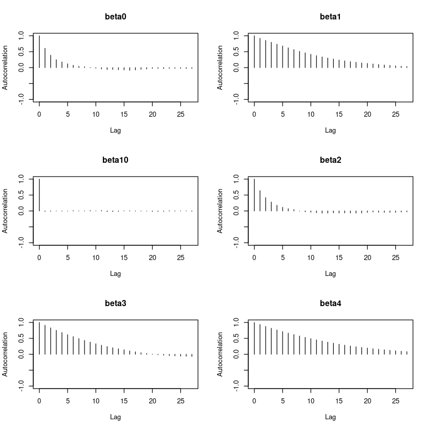

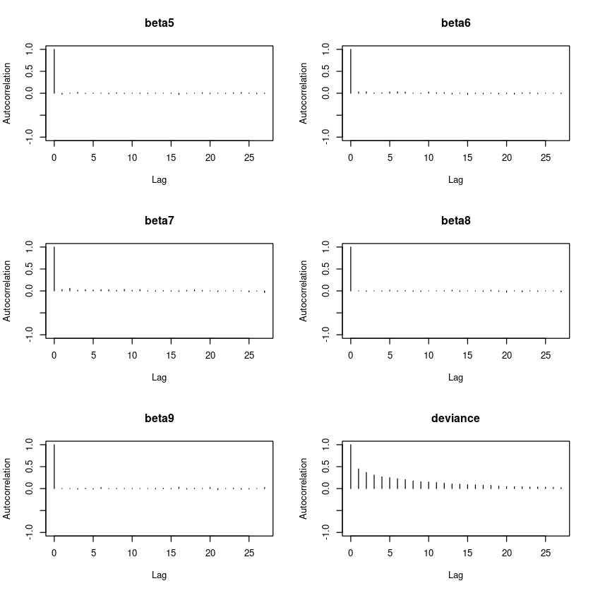

```r
coda::autocorr.plot(line.coda1)
```

Agora, observando a distribuição dos parâmetros, podemos esperar que a maior parte dos parâmetros possuam distribuição aproximadamente simétrica e unimodal. Já para os parâmetros com alta autoccorelação, esses possuiram, provavelmente, uma distribuição diferente dá que é esperado em caso ideal.

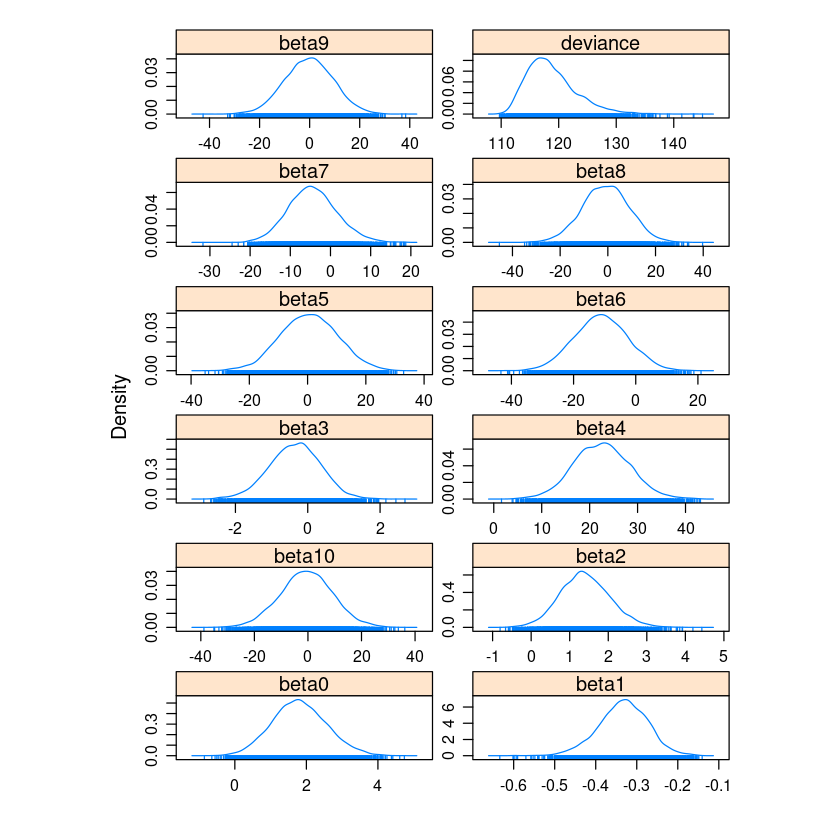

```r
lattice::densityplot(line.coda1)
```

O comportamento esperado foi obtido por todas as variáveis, inclusive aquela que não possuíram um bom desempenho nas análises anteriores. Entretanto, essas que possuiram um mal desempenho e já estão tomando nossa atenção, beta2,3 e 4, possuem ligeira assimetria, por pouco não fugindo do que se espera de uma distribuição unimodal.

Vamos agora observar o intervalo de credibilidade dos parâmetros, onde espera-se que hajam linhas aproximadamente horizontais e sem grande amplitude. Aqueles parâmetros que possuírem o valor 0 no intervalo de credibilidade são considerados parâmetros não relevantes, uma vez que podem anular uma variável do modelo. Veja a seguir

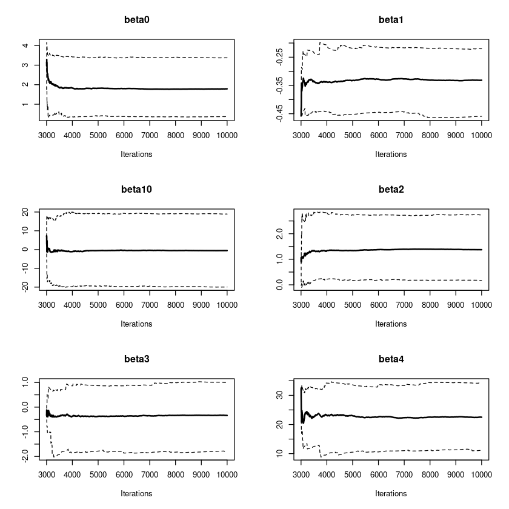

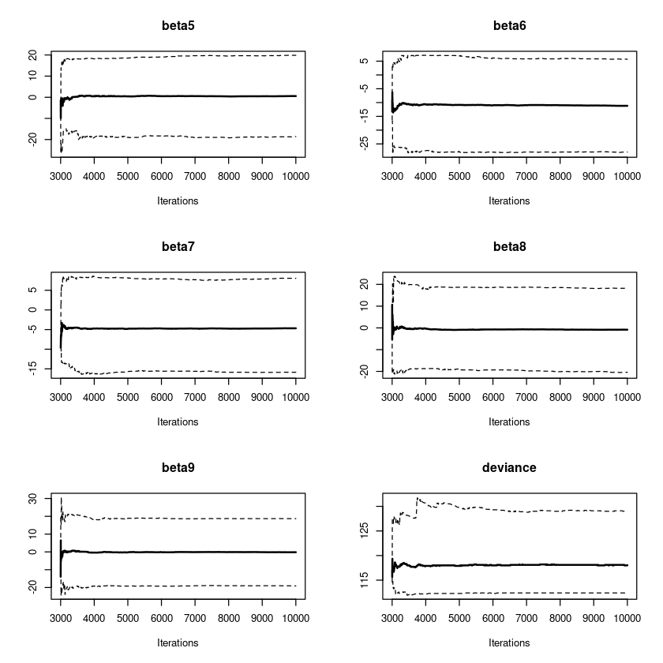

```r
coda::cumuplot(line.coda1)
```

Outra maneira de observar os mesmos resultados é a partir da seguinte tabela:

```r
summary(line.coda1)
```

```
Iterations = 3001:10000
Thinning interval = 1
Number of chains = 1
Sample size per chain = 7000

1. Empirical mean and standard deviation for each variable,
   plus standard error of the mean:

             Mean      SD  Naive SE Time-series SE
beta0      1.8080 0.76042 0.0090887       0.016133
beta1     -0.3334 0.06036 0.0007215       0.003408
beta10    -0.5555 9.88988 0.1182067       0.118207
beta2      1.4024 0.65161 0.0077882       0.014893
beta3     -0.3521 0.70893 0.0084733       0.035295
beta4     22.5388 5.86077 0.0700496       0.383171
beta5      0.5485 9.82058 0.1173784       0.114868
beta6    -11.1349 8.65252 0.1034173       0.120946
beta7     -4.4351 6.04843 0.0722926       0.089951
beta8     -0.8699 9.88079 0.1180981       0.118098
beta9     -0.2272 9.67651 0.1156564       0.115656
deviance 118.7369 4.31063 0.0515218       0.142835

2. Quantiles for each variable:

             2.5%      25%      50%      75%   97.5%
beta0      0.3696   1.2950   1.7870   2.3062   3.374
beta1     -0.4591  -0.3717  -0.3315  -0.2920  -0.220
beta10   -19.9605  -7.0347  -0.5303   5.9915  18.901
beta2      0.1696   0.9547   1.3750   1.8260   2.738
beta3     -1.7870  -0.8208  -0.3362   0.1294   0.999
beta4     11.1685  18.5300  22.5100  26.4400  34.260
beta5    -18.5922  -6.1842   0.5654   7.3333  19.841
beta6    -27.9400 -16.9625 -11.1800  -5.2918   5.707
beta7    -15.8602  -8.5920  -4.6705  -0.6003   8.048
beta8    -20.4200  -7.4460  -0.8230   5.7470  18.280
beta9    -19.0907  -6.7542  -0.1628   6.3820  18.700
deviance 112.4000 115.6000 118.0500 121.1000 129.002
```

Aqui podemos observar que apenas as variáveis correspondentes aos parâmetros de beta0, beta1, beta2 e beta4 não possuem 0 no intervalo de credibilidade. Portanto, um novo modelo será construído apenas com essas variáveis.

# Segundo modelo

Como os parâmetros *beta3*, *beta5*, *beta6*, *beta7*, *beta8*, *beta9* e *beta10* se mostraram insignificantes, contruímos um modelo apenas com as variáveis que descrevem o desvio padrão de *area*, *texture* e *radius* das amostras. Mantendo o mesmo N e com 10000 iterações, sendo dessas 3000 de *bunin*, e - a principio - thin de 1, executaremos duas cadeias, na qual uma inicia seus parâmetros com valor igual a 0 e a outra inicia com os valores definidos anteriormente.

```r
# data são os nomes das variáveis que possui os dados a serem analisados
data<-list("y", "N","area", "texture", "radius")

# os parametros a serem definidos
params<-c("beta0", "beta1", "beta2", "beta4")

model <- function(){
    for(i in 1:N){
        y[i] ~ dbern(p[i])
        logit(p[i]) <- beta0 + beta1*area[i] + beta2*texture[i] + beta4*radius[i]
    }
    beta0 ~ dnorm(0, .01)
    beta1 ~ dnorm(0, .01)
    beta2 ~ dnorm(0, .01)
    beta4 ~ dnorm(0, .01)
}

# definindo valor inicial dos parâmetros
inits1<-list( beta0 = 0, beta1=0, beta2=0, beta4=0)
inits2<-list( beta0 = 1.8080, beta1=-0.3334, beta2=1.4024, beta4=22.5388)

inits<-list(inits1, inits2)

#criando um arquivo com o modelo pra conseguir usa-lo na biblioteca
model.file <- file.path("/home/ddeam/Documentos/Bayesian", "model2.txt")
write.model(model, model.file)
```

```r
# a execução em si
out2<-R2OpenBUGS::bugs(data, inits, params, model.file, n.chains = 2, n.iter=10000, n.burnin =3000, n.thin = 1 , DIC = TRUE, codaPkg = TRUE)
line.coda2 <- R2OpenBUGS::read.bugs(out2)
```

```
Abstracting beta0 ... 7000 valid values
Abstracting beta1 ... 7000 valid values
Abstracting beta2 ... 7000 valid values
Abstracting beta4 ... 7000 valid values
Abstracting deviance ... 7000 valid values
Abstracting beta0 ... 7000 valid values
Abstracting beta1 ... 7000 valid values
Abstracting beta2 ... 7000 valid values
Abstracting beta4 ... 7000 valid values
Abstracting deviance ... 7000 valid values
```

Podemos, agora, analisar o histórico de comportamento das cadeias.

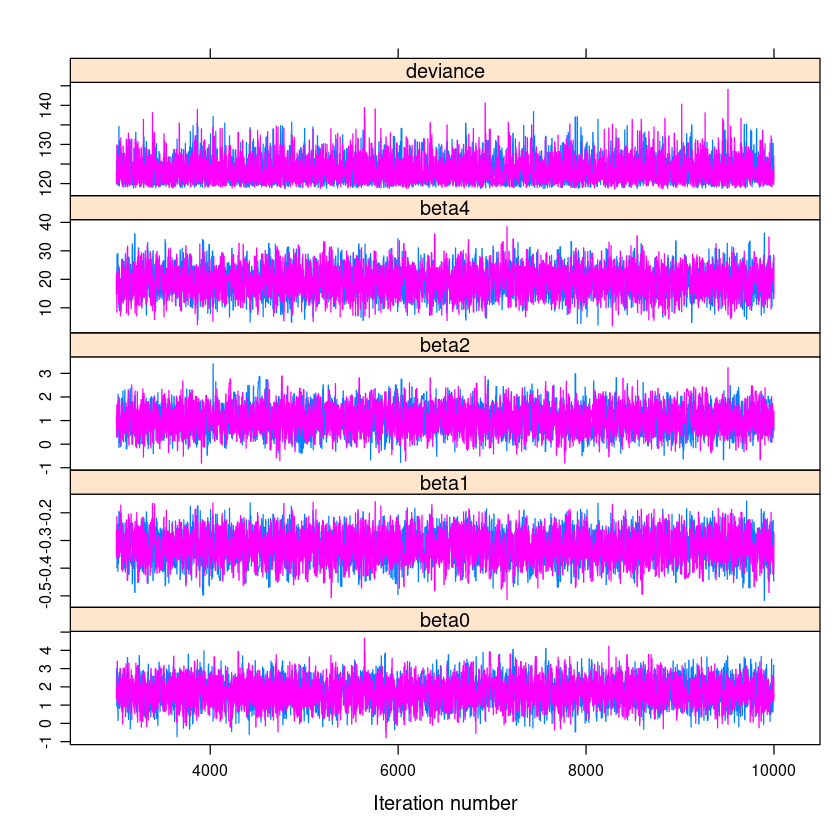

```r
lattice::xyplot(line.coda2)
```

Como todas as cadeis apresentam um comportamento que se adequa ao esperado, podemos observar agora a autocorelação das cadeias.

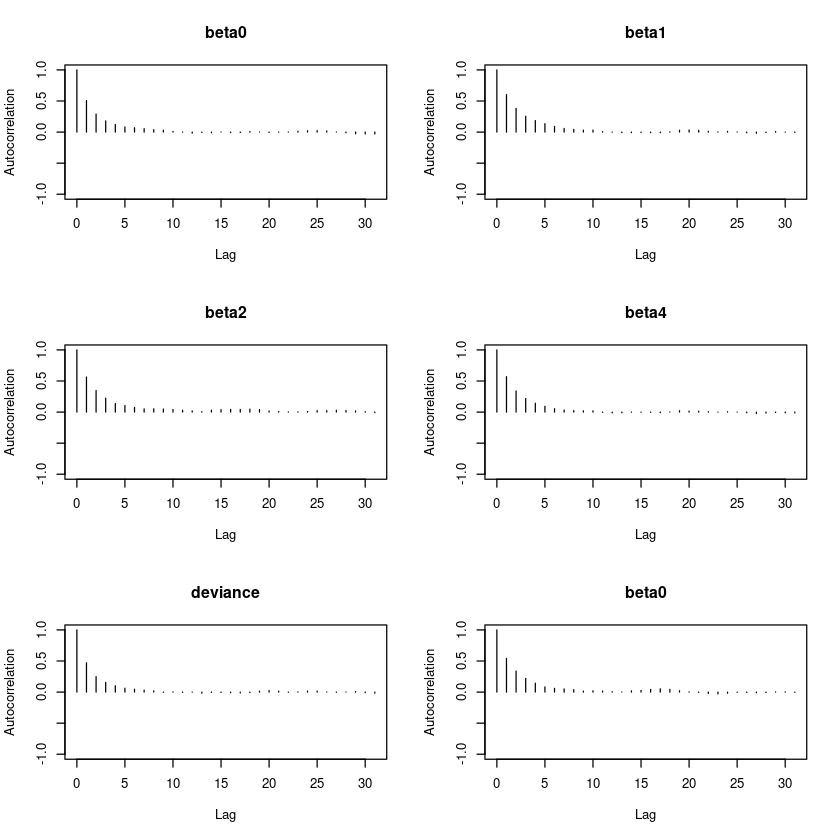

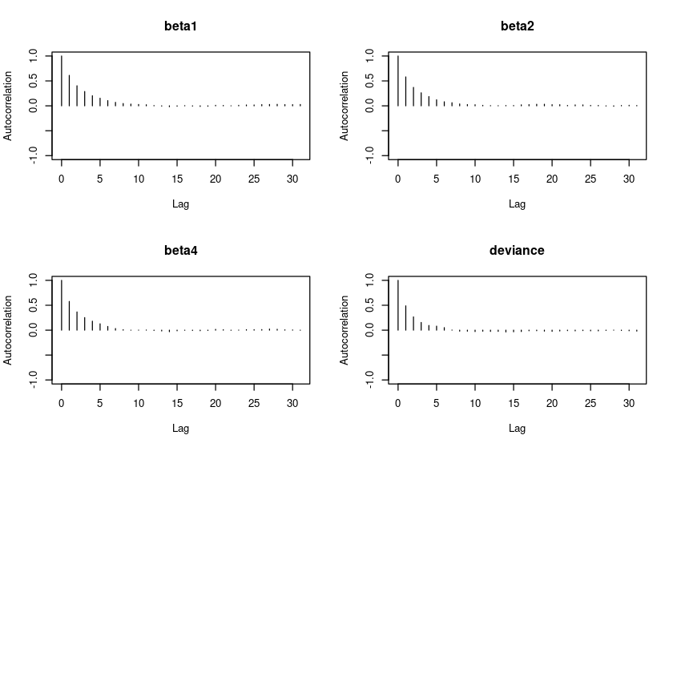

```r
coda::autocorr.plot(line.coda2)
```

Em ambas as cadeias foi possível observar certa autocorrelação em todos os parâmetros. Antes de Seguirmos para a análise da distribuição de densidade desses parâmetros, iremos aumentar o *thin* para 3 e verificar novamente a autocorrelação das cadeias.

```r
# a execução em si
out2<-R2OpenBUGS::bugs(data, inits, params, model.file, n.chains = 2, n.iter=10000, n.burnin =3000, n.thin = 3, DIC = TRUE, codaPkg = TRUE)
line.coda2 <- R2OpenBUGS::read.bugs(out2)
```

```
Abstracting beta0 ... 7000 valid values
Abstracting beta1 ... 7000 valid values
Abstracting beta2 ... 7000 valid values
Abstracting beta4 ... 7000 valid values
Abstracting deviance ... 7000 valid values
Abstracting beta0 ... 7000 valid values
Abstracting beta1 ... 7000 valid values
Abstracting beta2 ... 7000 valid values
Abstracting beta4 ... 7000 valid values
Abstracting deviance ... 7000 valid values
```

Observando a autocorrelação das cadeias:

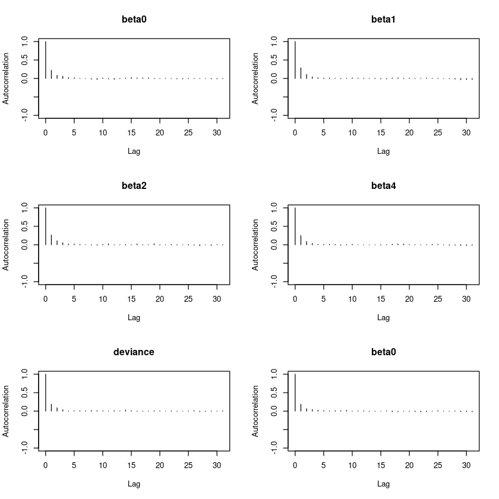

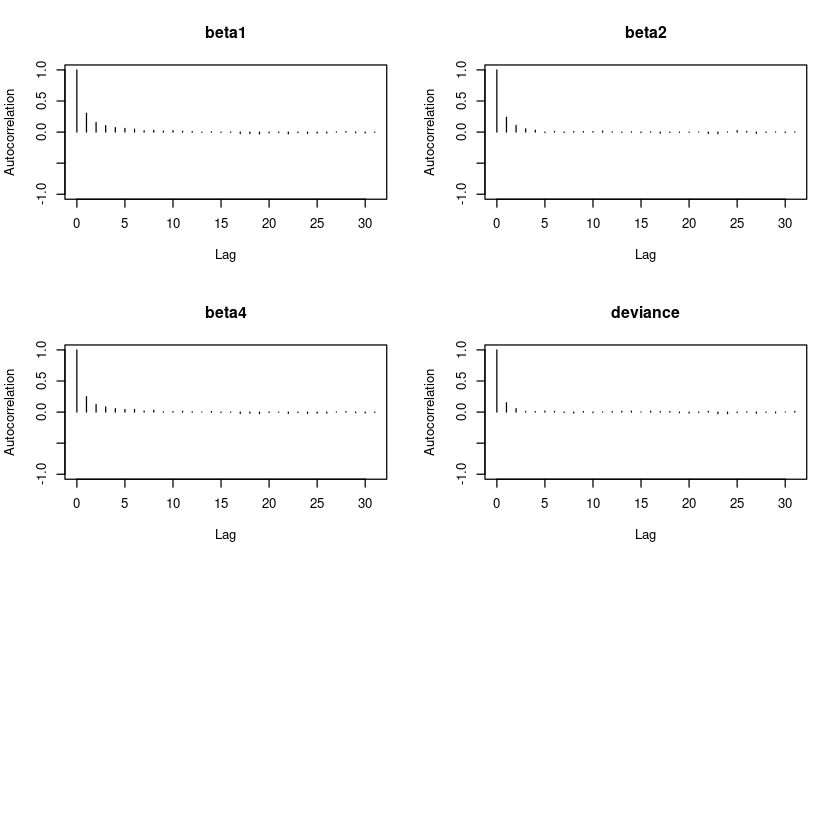

```r
coda::autocorr.plot(line.coda2)
```

Podemos observar uma melhora na autocorrelação das cadeias. Provavelmente, o aumento do *thin* melhoraria ainda mais esse aspecto, mas presseguiremos desta maneira.

Vamos agora analisar a distribuição de densidade dos parâmetros, lembrando que desejamos que sejam simétricos e unimodais.

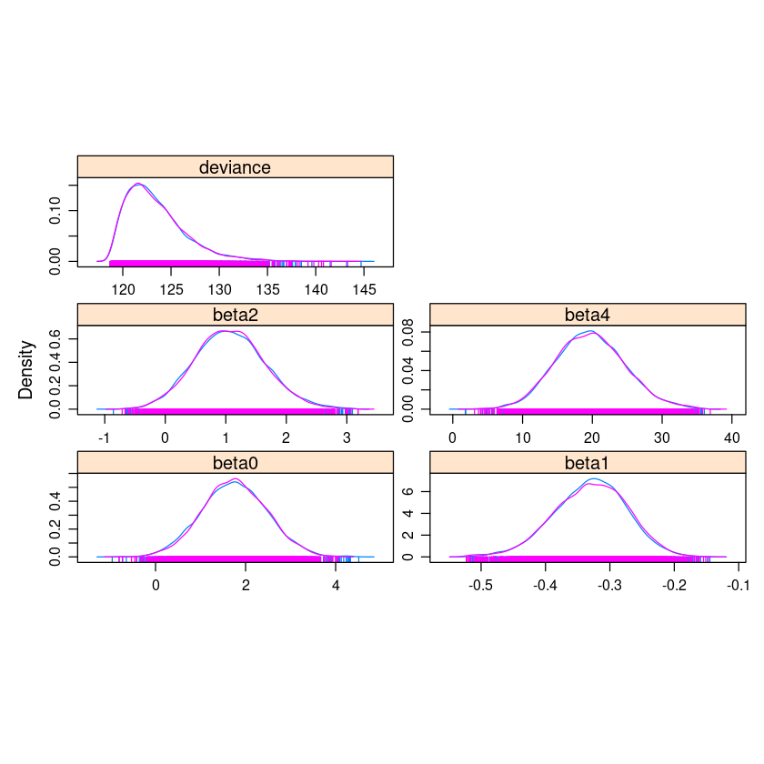

```r
lattice::densityplot(line.coda2)
```

Aqui, vemos que todos os parâmetros atendem nossas espectativas sobre suas devidas distribuições de densidade. Agora, observaremos o critério de Gelman Rubin, o qual desejamos que esteja próximo de 1, o que indica um bom ajuste do modelo aos dados.

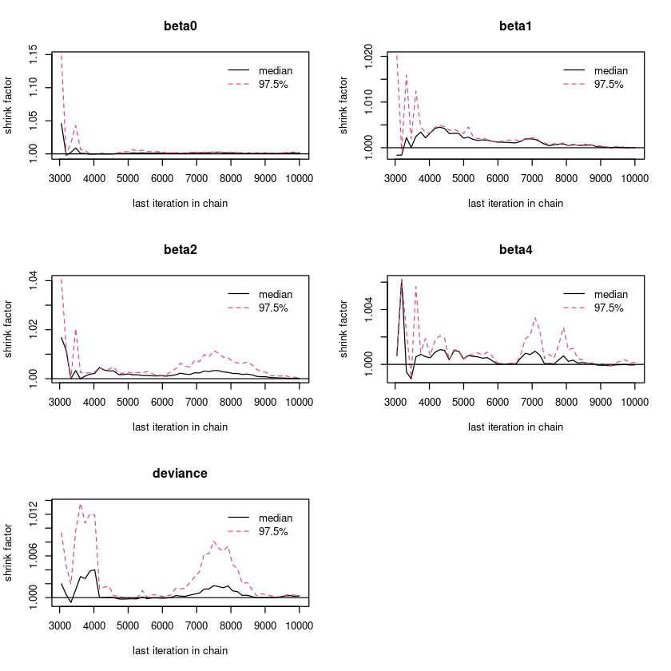

```r
coda::gelman.plot(line.coda2)
```

Como todos os parâmetros estão próximos a 1, podemos concluir que este é um modelo bem ajustado aos dados. Veja a seguir um sumário descritivo mais detalhado do modelo.

```r
summary(line.coda2)
```

```
Iterations = 3001:10000
Thinning interval = 1
Number of chains = 2
Sample size per chain = 7000

1. Empirical mean and standard deviation for each variable,
   plus standard error of the mean:

             Mean      SD  Naive SE Time-series SE
beta0      1.7564 0.72288 0.0061095      0.0080187
beta1     -0.3303 0.05686 0.0004805      0.0007218
beta2      1.0715 0.58289 0.0049264      0.0067942
beta4     19.7521 4.99131 0.0421843      0.0602212
deviance 123.4471 3.13205 0.0264707      0.0328526

2. Quantiles for each variable:

              2.5%      25%      50%      75%    97.5%
beta0      0.34528   1.2670   1.7525   2.2452   3.1940
beta1     -0.44751  -0.3679  -0.3281  -0.2908  -0.2239
beta2     -0.03099   0.6710   1.0580   1.4480   2.2780
beta4     10.44000  16.3200  19.6600  23.0700  30.1102
deviance 119.30000 121.1000 122.8000 125.0000 131.4000
```

# Observando os DICs